# Сборный проект №2

# Восстановление золота из руды

Необходимо подготовить прототип модели машинного обучения для компании «Цифры» которая занимается разработкой решения для эффективной работы промышленных предприятий.

Модель должна предсказать коэффициент восстановления золота из золотосодержащей руды. Для этого будем использовать данные с параметрами добычи и очистки.

Модель поможет оптимизировать производство, чтобы не запускать предприятие с убыточными характеристиками.

# Содержание

## Подготовка данных

```python
import pandas as pd
import numpy as np
import matplotlib.pyplot as plt
from tqdm import tqdm
from sklearn.model_selection import cross_val_score
from sklearn.metrics import make_scorer, mean_absolute_error
from sklearn.linear_model import LinearRegression
from sklearn.tree import DecisionTreeRegressor
from sklearn.ensemble import RandomForestRegressor
from sklearn.dummy import DummyRegressor
import warnings
```

```python
warnings.filterwarnings('ignore')
pd.set_option('display.max_columns', None)
pd.set_option('display.max_rows', None)
```

### Изучение файлов

Данные находятся в трех файлах. Посмотрим, что они из себя представляют.

```python
df_train = pd.read_csv('gold_recovery_train.csv')
df_test = pd.read_csv('gold_recovery_test.csv')
df_full = pd.read_csv('gold_recovery_full.csv')
```

- `df_train` - обучающая выборка;
- `df_test` - тестовая выборка;
- `df_full` - исходные данные.

```python
df_train.head()
```

|  | date | final.output.concentrate_ag | final.output.concentrate_pb | final.output.concentrate_sol | final.output.concentrate_au | final.output.recovery | final.output.tail_ag | final.output.tail_pb | final.output.tail_sol | final.output.tail_au | primary_cleaner.input.sulfate | primary_cleaner.input.depressant | primary_cleaner.input.feed_size | primary_cleaner.input.xanthate | primary_cleaner.output.concentrate_ag | primary_cleaner.output.concentrate_pb | primary_cleaner.output.concentrate_sol | primary_cleaner.output.concentrate_au | primary_cleaner.output.tail_ag | primary_cleaner.output.tail_pb | primary_cleaner.output.tail_sol | primary_cleaner.output.tail_au | primary_cleaner.state.floatbank8_a_air | primary_cleaner.state.floatbank8_a_level | primary_cleaner.state.floatbank8_b_air | primary_cleaner.state.floatbank8_b_level | primary_cleaner.state.floatbank8_c_air | primary_cleaner.state.floatbank8_c_level | primary_cleaner.state.floatbank8_d_air | … |
| --- | --- | --- | --- | --- | --- | --- | --- | --- | --- | --- | --- | --- | --- | --- | --- | --- | --- | --- | --- | --- | --- | --- | --- | --- | --- | --- | --- | --- | --- | --- |
| 0 | 2016-01-15 00:00:00 | 6.055403 | 9.889648 | 5.507324 | 42.192020 | 70.541216 | 10.411962 | 0.895447 | 16.904297 | 2.143149 | 127.092003 | 10.128295 | 7.25 | 0.988759 | 8.547551 | 10.389648 | 19.529297 | 34.174427 | 14.936526 | 2.534912 | 7.476074 | 2.106679 | 1549.775757 | -498.912140 | 1551.434204 | -516.403442 | 1549.873901 | -498.666595 | 1554.367432 | … |
| 1 | 2016-01-15 01:00:00 | 6.029369 | 9.968944 | 5.257781 | 42.701629 | 69.266198 | 10.462676 | 0.927452 | 16.634514 | 2.224930 | 125.629232 | 10.296251 | 7.25 | 1.002663 | 8.558743 | 10.497069 | 19.369147 | 34.118526 | 16.250511 | 3.049646 | 6.733907 | 2.353017 | 1576.166671 | -500.904965 | 1575.950626 | -499.865889 | 1575.994189 | -499.315107 | 1574.479259 | … |
| 2 | 2016-01-15 02:00:00 | 6.055926 | 10.213995 | 5.383759 | 42.657501 | 68.116445 | 10.507046 | 0.953716 | 16.208849 | 2.257889 | 123.819808 | 11.316280 | 7.25 | 0.991265 | 8.603505 | 10.354494 | 19.167579 | 33.969464 | 16.491823 | 3.124664 | 6.471768 | 2.416800 | 1601.556163 | -499.997791 | 1600.386685 | -500.607762 | 1602.003542 | -500.870069 | 1599.541515 | … |
| 3 | 2016-01-15 03:00:00 | 6.047977 | 9.977019 | 4.858634 | 42.689819 | 68.347543 | 10.422762 | 0.883763 | 16.532835 | 2.146849 | 122.270188 | 11.322140 | 7.25 | 0.996739 | 7.221879 | 8.496563 | 15.978538 | 28.260743 | 16.024359 | 2.960362 | 6.843791 | 2.262051 | 1599.968720 | -500.951778 | 1600.659236 | -499.677094 | 1600.304144 | -500.727997 | 1600.449520 | … |
| 4 | 2016-01-15 04:00:00 | 6.148599 | 10.142511 | 4.939416 | 42.774141 | 66.927016 | 10.360302 | 0.792826 | 16.525686 | 2.055292 | 117.988169 | 11.913613 | 7.25 | 1.009869 | 9.089428 | 9.986786 | 19.199864 | 33.044932 | 16.480185 | 3.112100 | 6.550154 | 2.277073 | 1601.339707 | -498.975456 | 1601.437854 | -500.323246 | 1599.581894 | -500.888152 | 1602.649541 | … |

```python
df_train.shape
```

```
(16860, 87)
```

```python
df_train.info()
```

```
<class 'pandas.core.frame.DataFrame'>
RangeIndex: 16860 entries, 0 to 16859
Data columns (total 87 columns):
 #   Column                                              Non-Null Count  Dtype
---  ------                                              --------------  -----
 0   date                                                16860 non-null  object
 1   final.output.concentrate_ag                         16788 non-null  float64
 2   final.output.concentrate_pb                         16788 non-null  float64
 3   final.output.concentrate_sol                        16490 non-null  float64
 4   final.output.concentrate_au                         16789 non-null  float64
 5   final.output.recovery                               15339 non-null  float64
 6   final.output.tail_ag                                16794 non-null  float64
 7   final.output.tail_pb                                16677 non-null  float64
 8   final.output.tail_sol                               16715 non-null  float64
 9   final.output.tail_au                                16794 non-null  float64
```

[output cut: 79 more lines]

```python
df_test.shape
```

```
(5856, 53)
```

```python
df_test.info()
```

```
<class 'pandas.core.frame.DataFrame'>
RangeIndex: 5856 entries, 0 to 5855
Data columns (total 53 columns):
 #   Column                                      Non-Null Count  Dtype
---  ------                                      --------------  -----
 0   date                                        5856 non-null   object
 1   primary_cleaner.input.sulfate               5554 non-null   float64
 2   primary_cleaner.input.depressant            5572 non-null   float64
 3   primary_cleaner.input.feed_size             5856 non-null   float64
 4   primary_cleaner.input.xanthate              5690 non-null   float64
 5   primary_cleaner.state.floatbank8_a_air      5840 non-null   float64
 6   primary_cleaner.state.floatbank8_a_level    5840 non-null   float64
 7   primary_cleaner.state.floatbank8_b_air      5840 non-null   float64
 8   primary_cleaner.state.floatbank8_b_level    5840 non-null   float64
 9   primary_cleaner.state.floatbank8_c_air      5840 non-null   float64
```

[output cut: 45 more lines]

```python
df_full.shape
```

```
(22716, 87)
```

```python
df_full.info()
```

```
<class 'pandas.core.frame.DataFrame'>
RangeIndex: 22716 entries, 0 to 22715
Data columns (total 87 columns):
 #   Column                                              Non-Null Count  Dtype
---  ------                                              --------------  -----
 0   date                                                22716 non-null  object
 1   final.output.concentrate_ag                         22627 non-null  float64
 2   final.output.concentrate_pb                         22629 non-null  float64
 3   final.output.concentrate_sol                        22331 non-null  float64
 4   final.output.concentrate_au                         22630 non-null  float64
 5   final.output.recovery                               20753 non-null  float64
 6   final.output.tail_ag                                22633 non-null  float64
 7   final.output.tail_pb                                22516 non-null  float64
 8   final.output.tail_sol                               22445 non-null  float64
 9   final.output.tail_au                                22635 non-null  float64
```

[output cut: 79 more lines]

Названия признаков строятся исходя из:

1. Названия этапа:
   - **rougher** — флотация
   - **primary_cleaner** — первичная очистка
   - **secondary_cleaner** — вторичная очистка
   - **final** — финальные характеристики
2. Типа параметра:
   - **input** — параметры сырья
   - **output** — параметры продукта
   - **state** — параметры, характеризующие текущее состояние этапа
   - **calculation** — расчётные характеристики
3. Непосредственно названия параметра

Данные индексируются датой и временем получения информации (признак **date**). Соседние по времени параметры схожие. По этой причине можем задать столбец `date` в качестве индекса во всех трех датафреймах.

```python
df_train.set_index('date', inplace=True)
```

```python
df_test.set_index('date', inplace=True)
```

```python
df_full.set_index('date', inplace=True)
```

**Вывод**

- Можем заметить, что во всех трех датасетах большое количество пропущенных значений, требуется их обработка.
- Некоторые параметры недоступны, потому что замеряются или рассчитываются значительно позже.
- Также замечаем, что `df_test` содержит только 53 признака, в отличие от `df_train` и `df_full`, где их по 87. Лишние признаки из `df_train` необходимо убрать.

### Проверка правильности расчетов эффективности обогащения

Необходимо удостовериться, что эффективность обогащения рассчитана верно. Вычислим её на обучающей выборке для признака **rougher.output.recovery**. После этого найдем **метрику MAE** между нашими расчётами и значением признака.

Эффективность обогащения (**Recovery**) рассчитывается по следующей формуле: $$Recovery = \frac{C ⋅ (F - T)}{F ⋅ (C - T)} ⋅ 100\%, $$

- **C** - доля золота в концентрате после флотации (в нашем случае признак **rougher.output.concentrate_au**),
- **F** — доля золота в сырье до флотации (признак **rougher.input.feed_au**);
- **T** — доля золота в отвальных хвостах после флотации (признак **rougher.output.tail_au**).

Посмотрев на формулу и вспомнив закон математики о запрете деления на ноль, нам необходимо исключить случаи, когда знаменатель расчетной формулы равен нулю. Такое происходит:

1. Если **rougher.output.concentrate_au == rougher.output.tail_au**,
2. Если **rougher.input.feed_au == 0**.

Проверим наличие объектов, удовлетворяющих этим условиям.

**Важное замечание:** чтобы успешно вычислить значение метрики MAE, нам необходимо избавиться от нулевых и пропущенных значений в некоторых признаках путем их удаления из рассматриваемого датасета. С другой стороны, отбрасывать временные куски технологического процесса не самое правильное решение, при будущем построении модели их правильнее оставить, предварительно преобразовав пропуски. Учитывая это, для проверки корректности расчета эффективности обогащения, будем рассматривать не саму обучающую выборку, а ее копию.

```python
df_train_mae = df_train.copy()
```

```python
# проверяем первое условие
len(df_train_mae[df_train_mae['rougher.output.concentrate_au']==df_train_mae['rougher.output.tail_au']])
```

```
0
```

```python
# проверяем второе условие
len(df_train_mae[df_train_mae['rougher.input.feed_au']==0])
```

```
1159
```

Видим, что в обучающей выборке присутствует 1159 нулевых значений признака **rougher.input.feed_au**, которые удалим.

```python
df_train_mae = df_train_mae[df_train_mae['rougher.input.feed_au']!=0]
```

Посмотрим, есть ли в рассматриваемых признаках пропуски. Их наличие не позволит вычислить метрику MAE.

```python
df_train_mae[['rougher.output.recovery', 'rougher.input.feed_au', 'rougher.output.concentrate_au', 'rougher.output.tail_au']].isna().sum()
```

```
rougher.output.recovery          1414
rougher.input.feed_au              83
rougher.output.concentrate_au      82
rougher.output.tail_au           1153
dtype: int64
```

Пропуски имеются, их следует удалить.

```python
df_train_mae.dropna(subset=['rougher.output.recovery'], inplace=True)
```

```python
# проверяем
df_train_mae[['rougher.output.recovery', 'rougher.input.feed_au', 'rougher.output.concentrate_au', 'rougher.output.tail_au']].isna().sum()
```

```
rougher.output.recovery          0
rougher.input.feed_au            0
rougher.output.concentrate_au    0
rougher.output.tail_au           0
dtype: int64
```

Функция **recovery_eval** рассчитывает эффективность обогащения по приведенной ранее формуле.

```python
def recovery_eval(row):
    input_au = row['rougher.input.feed_au']
    output_au = row['rougher.output.concentrate_au']
    tail_au = row['rougher.output.tail_au']
    result = ((output_au * (input_au - tail_au)) / (input_au * (output_au - tail_au))) * 100
    return result
```

Применяем функцию и сохраняем рассчитанные значения эффективности в признаке **rougher.output.recovery_eval**.

```python
df_train_mae['rougher.output.recovery_eval'] = df_train_mae.apply(recovery_eval, axis=1)
```

Теперь можем сравнить значения эффективности обогащения, представленные в датасете и расчитанные нами. Рассчитаем метрику MAE.

```python
round(mean_absolute_error(df_train_mae['rougher.output.recovery'], df_train_mae['rougher.output.recovery_eval']), 3)
```

```
0.0
```

**Вывод**

Получили **MAE = 0** для параметра эффективности обогащения **rougher.output.recovery**, следовательно эффективность, представленная в исходной выборке рассчитана верно.

### Анализ тестовой выборки

Найдем признаки, отсутствующие в таблице `df_test`, но присутствующие в обучающей `df_train` и исходной `df_full` выборках.

```python
df_train.columns[~df_train.columns.isin(df_test.columns)]
```

```
Index(['final.output.concentrate_ag', 'final.output.concentrate_pb',
       'final.output.concentrate_sol', 'final.output.concentrate_au',
       'final.output.recovery', 'final.output.tail_ag', 'final.output.tail_pb',
       'final.output.tail_sol', 'final.output.tail_au',
       'primary_cleaner.output.concentrate_ag',
       'primary_cleaner.output.concentrate_pb',
       'primary_cleaner.output.concentrate_sol',
       'primary_cleaner.output.concentrate_au',
       'primary_cleaner.output.tail_ag', 'primary_cleaner.output.tail_pb',
       'primary_cleaner.output.tail_sol', 'primary_cleaner.output.tail_au',
       'rougher.calculation.sulfate_to_au_concentrate',
       'rougher.calculation.floatbank10_sulfate_to_au_feed',
       'rougher.calculation.floatbank11_sulfate_to_au_feed',
       'rougher.calculation.au_pb_ratio', 'rougher.output.concentrate_ag',
       'rougher.output.concentrate_pb', 'rougher.output.concentrate_sol',
       'rougher.output.concentrate_au', 'rougher.output.recovery',
       'rougher.output.tail_ag', 'rougher.output.tail_pb',
       'rougher.output.tail_sol', 'rougher.output.tail_au',
       'secondary_cleaner.output.tail_ag', 'secondary_cleaner.output.tail_pb',
       'secondary_cleaner.output.tail_sol',
       'secondary_cleaner.output.tail_au'],
      dtype='object')
```

```python
len(df_train.columns[~df_train.columns.isin(df_test.columns)])
```

```
34
```

Получили список из 34 признаков. Рассмотрим подробнее, что это за параметры и почему они отсутствуют в тестовой выборке.

Можем заметить, что все представленные параметры относятся к типам **output** и **calculation** для всех четырех этапов технологического процесса. Напомним, что данные типы характеризуют параметры продукта, а также расчетные характеристики, получаемые и вычисляемые по завершении каждого этапа технологического процесса, их отсутствие в тестовой выборке выглядит логичным.

Также в тестовом наборе данных отсутствуют целевые признаки **rougher.output.recovery** и **final.output.recovery**. Это означает, что для проверки качества модели, предсказанные значения целевых признаков необходимо будет сравнивать с фактическими, содержащимися в исходной `df_full` выборке.

Наконец, такие признаки, как **final.output.concentrate_au**, **final.output.tail_au**, **rougher.output.concentrate_au** и **rougher.output.tail_au** включены в расчетную формулу целевых признаков **rougher.output.recovery** и **final.output.recovery**, поэтому их отсутствие в тестовой выборке связано с тем, чтобы исключить утечку признака.

### Предобработка данных

Предобработку будем проводить следующим образом:

1. Удаление лишних признаков из обучающей выборки.
2. Обработка пропущенных значений.
3. Проверка дубликатов.
4. Отделение целевых признаков в обучающей и тестовой выборках.

Как говорили в п. 1.3, количество признаков в обучающей и тестовой выборках разнится. По условию, построенная нами модель должна предсказать коэффициент восстановления золота из золотосодержащей руды по входным параметрам добычи и очистки. В связи с этим, доступные нам параметры в обучающей выборке, которые характеризуют выходные характеристики этапов технологического процесса (например, отвальные хвосты или концентраты металлов в руде), окажут негативное влияние на качество модели. Поэтому, считаем необходимым удалить все признаки из обучающей выборки, которые отсутствуют в тестовой выборке, за исключением целевых: **rougher.output.recovery** и **final.output.recovery**.

```python
df_train = df_train.drop(columns=['final.output.concentrate_ag', 'final.output.concentrate_pb','final.output.concentrate_sol',
                          'final.output.concentrate_au','final.output.tail_ag', 'final.output.tail_pb',
                          'final.output.tail_sol', 'final.output.tail_au', 'primary_cleaner.output.concentrate_ag',
                          'primary_cleaner.output.concentrate_pb', 'primary_cleaner.output.concentrate_sol',
                          'primary_cleaner.output.concentrate_au', 'primary_cleaner.output.tail_ag',
                          'primary_cleaner.output.tail_pb', 'primary_cleaner.output.tail_sol',
                          'primary_cleaner.output.tail_au', 'rougher.calculation.sulfate_to_au_concentrate',
                          'rougher.calculation.floatbank10_sulfate_to_au_feed',
                          'rougher.calculation.floatbank11_sulfate_to_au_feed', 'rougher.calculation.au_pb_ratio',
                          'rougher.output.concentrate_ag', 'rougher.output.concentrate_pb', 'rougher.output.concentrate_sol',
                          'rougher.output.concentrate_au', 'rougher.output.tail_ag', 'rougher.output.tail_pb',
                          'rougher.output.tail_sol', 'rougher.output.tail_au', 'secondary_cleaner.output.tail_ag',
                          'secondary_cleaner.output.tail_pb', 'secondary_cleaner.output.tail_sol',
                          'secondary_cleaner.output.tail_au'], axis=1)
```

Еще раз посмотрим на количество пропусков в датафреймах. Чтобы исключить дублирование кода, используем функцию **nan_percent**.

```python
def nan_percent(data):
    new_data = data.isna().sum().to_frame()
    new_data = new_data.rename(columns = {0: 'missing_values'})
    new_data['% of total'] = ((new_data['missing_values'] / data.shape[0])*100).round(3)
    return new_data.sort_values(by = 'missing_values', ascending = False)
```

```python
# обучающая выборка
nan_percent(df_train)
```

|  | missing_values | % of total |
| --- | --- | --- |
| rougher.output.recovery | 2573 | 15.261 |
| rougher.input.floatbank11_xanthate | 1904 | 11.293 |
| final.output.recovery | 1521 | 9.021 |
| primary_cleaner.input.sulfate | 1307 | 7.752 |
| primary_cleaner.input.depressant | 1262 | 7.485 |
| rougher.input.floatbank10_sulfate | 1044 | 6.192 |
| primary_cleaner.input.xanthate | 985 | 5.842 |
| rougher.input.floatbank11_sulfate | 623 | 3.695 |
| rougher.state.floatbank10_e_air | 603 | 3.577 |
| rougher.input.feed_rate | 513 | 3.043 |
| rougher.input.feed_size | 417 | 2.473 |
| secondary_cleaner.state.floatbank2_a_air | 363 | 2.153 |
| rougher.input.floatbank10_xanthate | 346 | 2.052 |
| rougher.input.feed_sol | 292 | 1.732 |
| rougher.input.feed_pb | 228 | 1.352 |
| secondary_cleaner.state.floatbank2_b_air | 155 | 0.919 |
| secondary_cleaner.state.floatbank4_a_air | 129 | 0.765 |
| secondary_cleaner.state.floatbank4_a_level | 113 | 0.670 |
| secondary_cleaner.state.floatbank3_a_level | 113 | 0.670 |
| secondary_cleaner.state.floatbank2_b_level | 112 | 0.664 |
| secondary_cleaner.state.floatbank3_b_level | 110 | 0.652 |
| secondary_cleaner.state.floatbank2_a_level | 109 | 0.647 |
| secondary_cleaner.state.floatbank3_b_air | 108 | 0.641 |
| secondary_cleaner.state.floatbank6_a_air | 103 | 0.611 |
| secondary_cleaner.state.floatbank3_a_air | 97 | 0.575 |
| secondary_cleaner.state.floatbank4_b_level | 93 | 0.552 |
| secondary_cleaner.state.floatbank4_b_air | 92 | 0.546 |
| secondary_cleaner.state.floatbank5_b_air | 85 | 0.504 |
| secondary_cleaner.state.floatbank5_a_level | 85 | 0.504 |
| secondary_cleaner.state.floatbank5_a_air | 85 | 0.504 |
| secondary_cleaner.state.floatbank6_a_level | 85 | 0.504 |
| secondary_cleaner.state.floatbank5_b_level | 84 | 0.498 |
| rougher.input.feed_au | 83 | 0.492 |
| rougher.input.feed_ag | 82 | 0.486 |
| rougher.state.floatbank10_f_air | 58 | 0.344 |
| rougher.state.floatbank10_f_level | 58 | 0.344 |
| rougher.state.floatbank10_d_air | 58 | 0.344 |
| rougher.state.floatbank10_a_level | 53 | 0.314 |
| rougher.state.floatbank10_a_air | 53 | 0.314 |
| rougher.state.floatbank10_b_level | 53 | 0.314 |
| rougher.state.floatbank10_b_air | 53 | 0.314 |
| rougher.state.floatbank10_c_air | 53 | 0.314 |
| rougher.state.floatbank10_e_level | 51 | 0.302 |
| rougher.state.floatbank10_d_level | 51 | 0.302 |
| rougher.state.floatbank10_c_level | 46 | 0.273 |
| primary_cleaner.state.floatbank8_b_air | 40 | 0.237 |
| primary_cleaner.state.floatbank8_a_air | 40 | 0.237 |
| primary_cleaner.state.floatbank8_d_air | 39 | 0.231 |
| primary_cleaner.state.floatbank8_c_air | 38 | 0.225 |
| primary_cleaner.state.floatbank8_a_level | 33 | 0.196 |
| primary_cleaner.state.floatbank8_d_level | 27 | 0.160 |
| primary_cleaner.state.floatbank8_c_level | 27 | 0.160 |
| primary_cleaner.state.floatbank8_b_level | 27 | 0.160 |
| primary_cleaner.input.feed_size | 0 | 0.000 |

```python
# тестовая выборка
nan_percent(df_test)
```

|  | missing_values | % of total |
| --- | --- | --- |
| rougher.input.floatbank11_xanthate | 353 | 6.028 |
| primary_cleaner.input.sulfate | 302 | 5.157 |
| primary_cleaner.input.depressant | 284 | 4.850 |
| rougher.input.floatbank10_sulfate | 257 | 4.389 |
| primary_cleaner.input.xanthate | 166 | 2.835 |
| rougher.input.floatbank10_xanthate | 123 | 2.100 |
| rougher.input.feed_sol | 67 | 1.144 |
| rougher.input.floatbank11_sulfate | 55 | 0.939 |
| rougher.input.feed_rate | 40 | 0.683 |
| secondary_cleaner.state.floatbank3_a_air | 34 | 0.581 |
| secondary_cleaner.state.floatbank2_b_air | 23 | 0.393 |
| rougher.input.feed_size | 22 | 0.376 |
| secondary_cleaner.state.floatbank2_a_air | 20 | 0.342 |
| rougher.state.floatbank10_f_air | 17 | 0.290 |
| rougher.state.floatbank10_e_air | 17 | 0.290 |
| rougher.state.floatbank10_d_air | 17 | 0.290 |
| rougher.state.floatbank10_b_air | 17 | 0.290 |
| rougher.state.floatbank10_a_air | 17 | 0.290 |
| rougher.state.floatbank10_c_air | 17 | 0.290 |
| rougher.input.feed_au | 16 | 0.273 |
| rougher.input.feed_pb | 16 | 0.273 |
| secondary_cleaner.state.floatbank6_a_air | 16 | 0.273 |
| secondary_cleaner.state.floatbank5_b_level | 16 | 0.273 |
| secondary_cleaner.state.floatbank5_b_air | 16 | 0.273 |
| secondary_cleaner.state.floatbank5_a_level | 16 | 0.273 |
| secondary_cleaner.state.floatbank5_a_air | 16 | 0.273 |
| secondary_cleaner.state.floatbank4_b_level | 16 | 0.273 |
| secondary_cleaner.state.floatbank4_b_air | 16 | 0.273 |
| secondary_cleaner.state.floatbank4_a_level | 16 | 0.273 |
| secondary_cleaner.state.floatbank4_a_air | 16 | 0.273 |
| secondary_cleaner.state.floatbank3_b_level | 16 | 0.273 |
| secondary_cleaner.state.floatbank3_b_air | 16 | 0.273 |
| secondary_cleaner.state.floatbank3_a_level | 16 | 0.273 |
| secondary_cleaner.state.floatbank2_b_level | 16 | 0.273 |
| primary_cleaner.state.floatbank8_a_air | 16 | 0.273 |
| secondary_cleaner.state.floatbank2_a_level | 16 | 0.273 |
| primary_cleaner.state.floatbank8_a_level | 16 | 0.273 |
| rougher.state.floatbank10_f_level | 16 | 0.273 |
| primary_cleaner.state.floatbank8_b_air | 16 | 0.273 |
| rougher.state.floatbank10_e_level | 16 | 0.273 |
| primary_cleaner.state.floatbank8_b_level | 16 | 0.273 |
| rougher.state.floatbank10_d_level | 16 | 0.273 |
| primary_cleaner.state.floatbank8_c_air | 16 | 0.273 |
| rougher.state.floatbank10_c_level | 16 | 0.273 |
| primary_cleaner.state.floatbank8_c_level | 16 | 0.273 |
| rougher.state.floatbank10_b_level | 16 | 0.273 |
| primary_cleaner.state.floatbank8_d_air | 16 | 0.273 |
| rougher.state.floatbank10_a_level | 16 | 0.273 |
| primary_cleaner.state.floatbank8_d_level | 16 | 0.273 |
| rougher.input.feed_ag | 16 | 0.273 |
| secondary_cleaner.state.floatbank6_a_level | 16 | 0.273 |
| primary_cleaner.input.feed_size | 0 | 0.000 |

```python
# исходная выборка
nan_percent(df_full)
```

|  | missing_values | % of total |
| --- | --- | --- |
| rougher.output.recovery | 3119 | 13.730 |
| rougher.output.tail_ag | 2737 | 12.049 |
| rougher.output.tail_sol | 2736 | 12.044 |
| rougher.output.tail_au | 2736 | 12.044 |
| rougher.input.floatbank11_xanthate | 2257 | 9.936 |
| secondary_cleaner.output.tail_sol | 2215 | 9.751 |
| final.output.recovery | 1963 | 8.641 |
| rougher.calculation.au_pb_ratio | 1627 | 7.162 |
| primary_cleaner.input.sulfate | 1609 | 7.083 |
| primary_cleaner.input.depressant | 1546 | 6.806 |
| rougher.input.floatbank10_sulfate | 1301 | 5.727 |
| primary_cleaner.input.xanthate | 1151 | 5.067 |
| primary_cleaner.output.concentrate_sol | 798 | 3.513 |
| rougher.input.floatbank11_sulfate | 678 | 2.985 |
| rougher.state.floatbank10_e_air | 620 | 2.729 |
| rougher.input.feed_rate | 553 | 2.434 |
| rougher.input.floatbank10_xanthate | 469 | 2.065 |
| primary_cleaner.output.concentrate_pb | 448 | 1.972 |
| rougher.input.feed_size | 439 | 1.933 |
| final.output.concentrate_sol | 385 | 1.695 |
| secondary_cleaner.state.floatbank2_a_air | 383 | 1.686 |
| rougher.input.feed_sol | 359 | 1.580 |
| primary_cleaner.output.tail_sol | 351 | 1.545 |
| final.output.tail_sol | 271 | 1.193 |
| rougher.input.feed_pb | 244 | 1.074 |
| final.output.tail_pb | 200 | 0.880 |
| rougher.output.concentrate_sol | 190 | 0.836 |
| secondary_cleaner.state.floatbank2_b_air | 178 | 0.784 |
| secondary_cleaner.state.floatbank4_a_air | 145 | 0.638 |
| secondary_cleaner.state.floatbank3_a_air | 131 | 0.577 |

[output cut: 56 more lines]

Несмотря на то, что процент пропущенных значений не велик (до 15%), отбрасывать их не будем. Как говорили ранее, объекты, представленные в датафреймах, индексируются датой и временем забора информации. Удаление объектов с пропусками в каком-либо признаке нарушит логику представления технологического процесса. Так как данные у нас связаны логически технологическим процессом, можем заполнить пропуски предыдущими значениями.

```python
df_train = df_train.fillna(method='ffill')
df_test = df_test.fillna(method='ffill')
df_full = df_full.fillna(method='ffill')
```

Следующим этапом предобработки является проверка дубликатов.

```python
df_train.duplicated().sum()
```

```
24
```

```python
df_test.duplicated().sum()
```

```
8
```

```python
df_full.duplicated().sum()
```

```
29
```

Видим, что дубликаты присутствуют во всех трех датафреймах. Удалим их.

```python
df_train.drop_duplicates(inplace=True)
```

```python
df_test.drop_duplicates(inplace=True)
```

```python
df_full.drop_duplicates(inplace=True)
```

**Вывод**

Провели предобработку данных, а именно: убрали лишние признаки из обучающей выборки, обработали пропущенные значения и удалили дубликаты.

## Анализ данных

### Анализ концентрации металлов (Au, Ag, Pb)

Посмотрим, как меняется концентрация металлов (Au, Ag, Pb) на различных этапах очистки. Рассмотрим исходную выборку `df_full`. Чтобы изобразить изменения в распределениях концентраций металлов графически, используем функцию **show_concentrate**.

```python
def show_concentrate(first_stage, second_stage, metal):
    plt.figure(figsize=(16, 5))
    plt.grid()
    plt.hist([first_stage, second_stage], bins=26, label=['1-й этап очистки', '2-й этап очистки'])
    plt.xlabel('Концентрация металла')
    plt.ylabel('Количество объектов')
    plt.title(f'Распределение концентрации {metal}')
    plt.legend(loc='upper left')
    plt.show()
    plt.figure(figsize=(16, 5))
    plt.grid()
    plt.boxplot([first_stage, second_stage], labels=['1-й этап очистки', '2-й этап очистки'])
    plt.title(f'Диаграмма размаха концентрации {metal}')
    plt.ylabel('Значение концентрации металла')
    plt.show()
    print('Среднее значение:', '\t', first_stage.mean(), '  \t\t\t\t\t', second_stage.mean())
    print('Медиана:', '\t\t', first_stage.median(), '  \t\t\t\t\t', second_stage.median())
```

**Анализ концентрации золота (Au)**

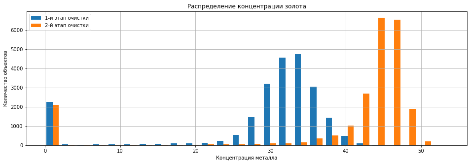

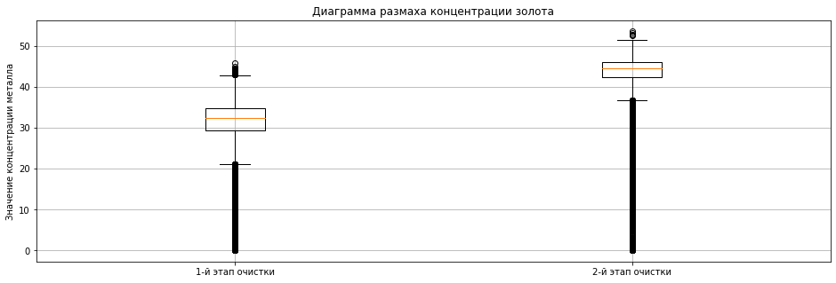

```
Среднее значение: 	 29.141098295435313   					 39.90696976709339
Медиана: 		 32.34817035517012   					 44.643242307544696
```

```python
show_concentrate(df_full['primary_cleaner.output.concentrate_au'], df_full['final.output.concentrate_au'], 'золота')
```

Посмотрев на диаграммы, можно сделать следующие **выводы**:

1. В финальном концентрате золота больше, чем в концентрате после первого этапа очистки, что подтверждается средними значениями. Скорее всего, увеличение концентрации золота достигается за счет уменьшения концентрации других металлов.
2. В выборке присутствует большое количество выбросов - значений концентрации золота, близких к нулю. Возможно, это связано с какими-либо сбоями оборудования или технологическими остановками, во время которых продолжался сбор данных о параметрах смеси золотоносной руды. Для построения наиболее эффективной модели, потребуется очистить выборки от таких выбросов.

**Анализ концентрации серебра (Ag)**

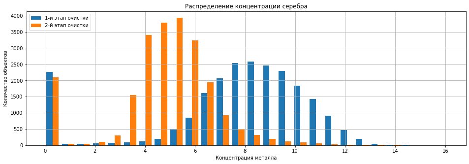

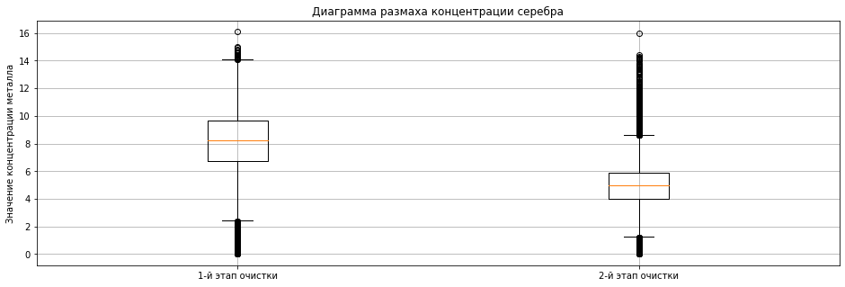

```
Среднее значение: 	 7.6725938414195225   					 4.770074487736419
Медиана: 		 8.258627401612117   					 4.950944866365352
```

```python
show_concentrate(df_full['primary_cleaner.output.concentrate_ag'], df_full['final.output.concentrate_ag'], 'серебра')
```

**Вывод:**

1. Наша гипотеза, сформулированная после анализа концентрации золота, подтвердилась. Действительно, в отличие от первого случая (с золотом), в ситуации с серебром наблюдаем уменьшение концентрации металла после второго этапа очистки в сравнении с первым.
2. Ситуация с аномальными сверхмалыми значениями концентрации металла аналогична предыдущему случаю. Предположение о сбоях оборудования подтверждается.

**Анализ концентрации свинца (Pb)**

Наконец, посмотрим, как меняется концентрация свинца(Pb) после первого и второго этапов очистки.

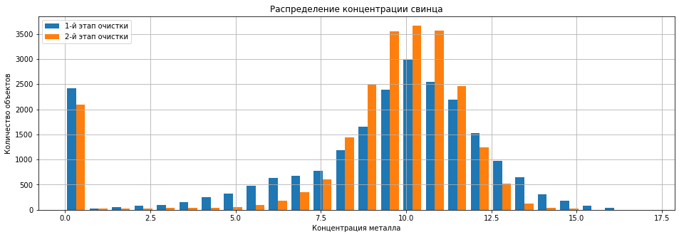

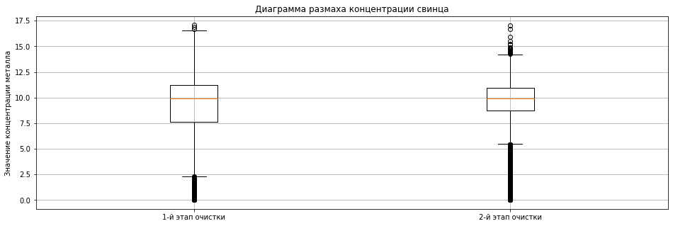

```
Среднее значение: 	 8.815952506325464   					 9.07348848905308
Медиана: 		 9.884161858558654   					 9.90888500822915
```

```python
show_concentrate(df_full['primary_cleaner.output.concentrate_pb'], df_full['final.output.concentrate_pb'], 'свинца')
```

**Вывод**

В случае с концентрацией свинца, наблюдается иная картина. Видим, что значения находятся примерно на одном и том же уровне (средние значения: 8.81 - после 1-го этапа, 9.07 - после 2-го этапа).

Неизменной остается только ситуация с выбросами - наблюдаем примерно такое же количество (2000-2300) близких к нулю объектов.

### Анализ размеров гранул сырья

Сравним распределения размеров гранул сырья на обучающей и тестовой выборках. Для графического отображения распределений используем функцию **show_feed_size**.

```python
def show_feed_size(train, test, stage):
    plt.figure(figsize=(16, 5))
    plt.grid()
    plt.hist([train, test], bins=30, label=['Обучающая выборка', 'Тестовая выборка'])
    plt.xlabel('Размер гранул сырья')
    plt.ylabel('Количество объектов')
    plt.title(f'Распределение размеров гранул сырья на этапе {stage}')
    plt.legend(loc='upper right')
    plt.show()
    plt.figure(figsize=(16, 5))
    plt.grid()
    plt.boxplot([train, test], labels=['Обучающая выборка', 'Тестовая выборка'])
    plt.title(f'Диаграмма размаха размеров гранул сырья на этапе {stage}')
    plt.ylabel('Значение размера гранул сырья')
    plt.show()
    print('Среднее значение:', '\t', train.mean(), '  \t\t\t\t\t', test.mean())
    print('Медиана:', '\t\t', train.median(), '  \t\t\t\t\t', test.median())
```

**Анализ размера гранул сырья на этапе флотации (rougher)**

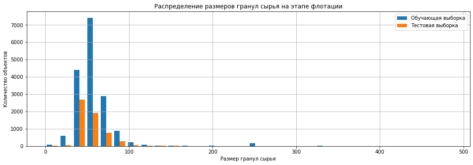

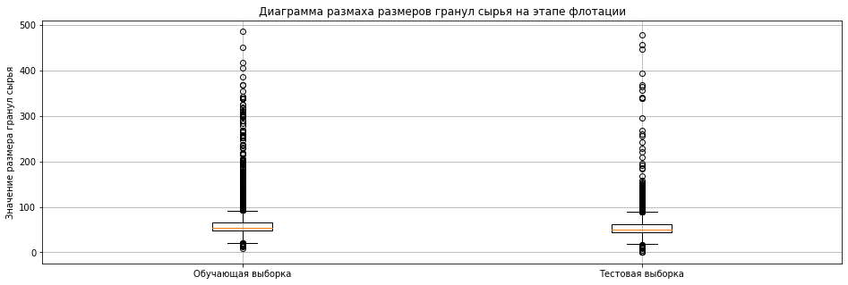

```
Среднее значение: 	 60.20140389385619   					 55.91449622463396
Медиана: 		 54.07470499802592   					 49.98365346158175
```

```python
show_feed_size(df_train['rougher.input.feed_size'], df_test['rougher.input.feed_size'], 'флотации')
```

**Вывод**

Формы распределений размеров гранул сырья на этапе флотации на обучающей и тестовой выборках схожие. Расхождение в средних значениях присутствуют, но не настолько критичные, чтобы проводить перебалансировку классов. В обеих выборках присутсвуют выбросы, которые необходимо отфильтровать.

**Анализ размера гранул сырья на этапе первичной очистки (primary_cleaner)**

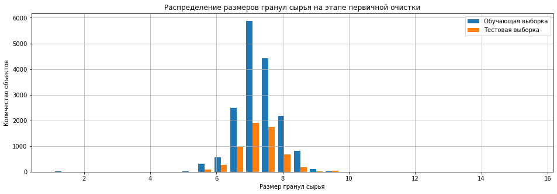

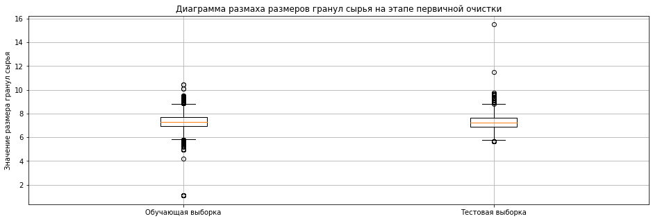

```
Среднее значение: 	 7.297768646132562   					 7.26452427620651
Медиана: 		 7.289249639479312   					 7.251667003737454
```

```python
show_feed_size(df_train['primary_cleaner.input.feed_size'], df_test['primary_cleaner.input.feed_size'], 'первичной очистки')
```

**Вывод**

Формы распределений размеров гранул сырья на этапе первичной очистки на обучающей и тестовой выборках также схожие. Расхождение в средних значениях на уровне погрешности. Как и на этапе флотации, нет необходимости проводить перебалансировку классов. Выбросов заметно меньше, но их обработка также необходима и важна.

### Анализ суммарной концентрации всех веществ (Au, Ag, Pb, Sol)

Исследуем суммарную концентрацию всех веществ на разных стадиях: в сырье, в черновом и финальном концентратах. Для этого все также будем рассматривать исходную выборку `df_full`, предварительно выполнив необоходимые вычисления по нахождению суммарных концентраций.

- в столбце `df_full['rougher.input.feed_sum']` будет храниться сумма всех веществ (Au, Ag, Pb и Sol) в **сырье**;
- в столбце `df_full['rougher.output.concentrate_sum']` будет храниться сумма всех веществ в **черновом концентрате**;
- в столбце `df_full['final.output.concentrate_sum']` будет храниться сумма всех веществ в **финальном концентрате**.

Вычислим суммарные значения концентрации веществ на каждом из этапов.

```python
df_full['rougher.input.feed_sum'] = (
    df_full['rougher.input.feed_au'] + df_full['rougher.input.feed_ag'] +
    df_full['rougher.input.feed_pb'] + df_full['rougher.input.feed_sol']
)
```

```python
df_full['rougher.output.concentrate_sum'] = (
    df_full['rougher.output.concentrate_au'] + df_full['rougher.output.concentrate_ag'] +
    df_full['rougher.output.concentrate_pb'] + df_full['rougher.output.concentrate_sol']
)
```

```python
df_full['final.output.concentrate_sum'] = (
    df_full['final.output.concentrate_au'] + df_full['final.output.concentrate_ag'] +
    df_full['final.output.concentrate_pb'] + df_full['final.output.concentrate_sol']
)
```

Теперь мы можем построить графики распределения и посмотреть, как же изменяется суммарная концентрация веществ на разных этапах технологического процесса.

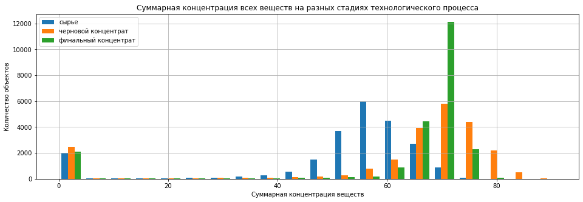

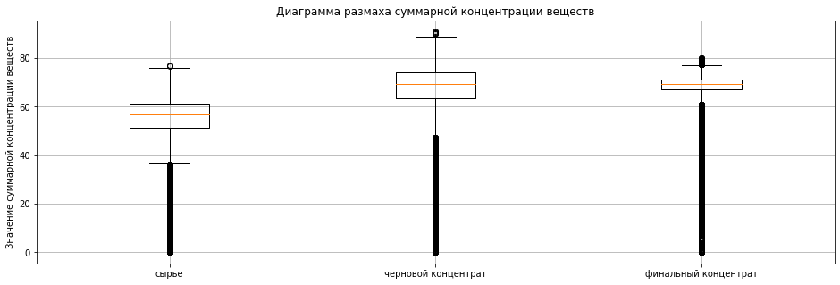

```
Среднее значение: 51.88837848952956      		 61.53975342513667        		 62.2908637351693
Медиана:          56.79332470597478 			 69.41657617268214 			 69.23976891820294
```

```python
raw_material = df_full['rougher.input.feed_sum']
rough_conc = df_full['rougher.output.concentrate_sum']
final_cons = df_full['final.output.concentrate_sum']
plt.figure(figsize=(16, 5))
plt.grid()
plt.hist(
    [raw_material, rough_conc, final_cons],
    bins=20,
    label=['сырье', 'черновой концентрат', 'финальный концентрат']
)
plt.xlabel('Суммарная концентрация веществ')
plt.ylabel('Количество объектов')
plt.title('Суммарная концентрация всех веществ на разных стадиях технологического процесса')
plt.legend(loc='upper left')
plt.show()
plt.figure(figsize=(16, 5))
plt.grid()
plt.boxplot(
    [raw_material, rough_conc, final_cons],
    labels=['сырье', 'черновой концентрат', 'финальный концентрат']
)
plt.title(f'Диаграмма размаха суммарной концентрации веществ')
plt.ylabel('Значение суммарной концентрации веществ')
plt.show()
print('Среднее значение:', raw_material.mean(), '     \t\t', rough_conc.mean(), '       \t\t', final_cons.mean())
print('Медиана:', '        ', raw_material.median(), '\t\t\t', rough_conc.median(), '\t\t\t', final_cons.median())
```

На графике распределения мы замечаем упомянутые ранее (в п. 2.1) аномальные значения вблизи нуля. Посмотрим на них подробнее.

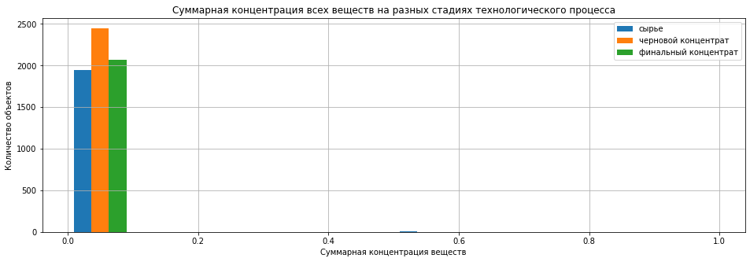

```python
plt.figure(figsize=(16, 5))
plt.grid()
plt.hist(
    [raw_material, rough_conc, final_cons],
    bins=10,
    range=(0, 1),
    label=['сырье', 'черновой концентрат', 'финальный концентрат']
)
plt.xlabel('Суммарная концентрация веществ')
plt.ylabel('Количество объектов')
plt.title('Суммарная концентрация всех веществ на разных стадиях технологического процесса')
plt.legend(loc='upper right')
plt.show()
```

Данные выбросы требуется удалить из рассматриваемых выборок (`df_train` и `df_test`) для повышения качества модели. Порогом отсечения будет 0.1.

```python
df_train = df_train[(
    df_train['rougher.input.feed_au'] +
    df_train['rougher.input.feed_ag'] +
    df_train['rougher.input.feed_pb'] +
    df_train['rougher.input.feed_sol'])>0.1]
```

```python
df_test = df_test[(
    df_test['rougher.input.feed_au'] +
    df_test['rougher.input.feed_ag'] +
    df_test['rougher.input.feed_pb'] +
    df_test['rougher.input.feed_sol'])>0.1]
```

Во время анализа размера гранул сырья на этапе флотации (п. 2.2), мы отметили большое количество выбросов. Оставим в наших выборках только те значений параметра **rougher.input.feed_size**, которые меньше 180.

```python
df_train = df_train[df_train['rougher.input.feed_size'] < 180]
```

```python
df_test = df_test[df_test['rougher.input.feed_size'] < 180]
```

**Вывод**

1. Провели анализ суммарной концентрации всех веществ на разных стадиях: в сырье, в черновом и финальном концентратах.
2. Заметили, что в ходе технологического процесса, суммарная концентрация всех веществ растет.
3. Обнаружили аномальные значения в суммарном распределении, а также в распределении размеров гранул на этапе флотации.
4. Очистили обучающую и тренировочную выборки от найденных выбросов.

## Модель

### Расчет метрики качества

Для решения задачи используем метрику качества — **sMAPE** (англ. Symmetric Mean Absolute Percentage Error, «симметричное среднее абсолютное процентное отклонение»). Метрика sMAPE вычисляется так: $$sMAPE = \frac{1}{N}\sum_{i=1}^N \frac{|y_i - \hat y_i|}{(|y_i| + |\hat y_i|) / 2} ⋅ 100\% $$

- $y_i$ - значение целевого признака для объекта с порядковым номером i (в нашем случае признак **rougher.output.recovery** и **final.output.recovery**);
- $\hat y_i$ — значение предсказания для объекта с порядковым номером i;
- **N** — количество объектов в выборке.

Поскольку нам необходимо спрогнозировать сразу две величины (**rougher.output.recovery** и **final.output.recovery**), то итоговая метрика будет складываться из двух величин: $$sMAPE_{итоговое} = 25\% ⋅ sMAPE_{rougher} + 75\% ⋅ sMAPE_{final}$$

Напишем функции **smape** и **smape_final** для вычисления итоговой sMAPE.

```python
def smape(target, predict):
    smape = (1 / len(target)) * 100 * ((abs(target-predict)) / ((abs(target+predict))/2)).sum()
    return smape
```

```python
def smape_final(smape_rougher, smape_final):
    result = (0.25 * smape_rougher) + (0.75 * smape_final)
    return result
```

### Обучение моделей

Перед тем, как обучать модели машинного обучения, выделим целевые признаки в обучающей и тестовой выборках.

```python
target1_train = df_train['rougher.output.recovery']
target2_train = df_train['final.output.recovery']
features_train = df_train.drop(['rougher.output.recovery','final.output.recovery'] , axis=1)
```

Ранее мы уже упоминали, что в тестовом наборе данных отсутствуют целевые признаки **rougher.output.recovery** и **final.output.recovery**, но в исходной выборке (`df_full`) они присутствуют. Следовательно, нам необходимо их присоединить к тестовой выборке, а затем уже выделить в целевые признаки (**target1_test и target2_test**).

```python
df_test = df_test.join(df_full['rougher.output.recovery'], how='left')
df_test = df_test.join(df_full['final.output.recovery'], how='left')
```

```python
target1_test = df_test['rougher.output.recovery']
target2_test = df_test['final.output.recovery']
features_test = df_test.drop(['rougher.output.recovery','final.output.recovery'] , axis=1)
```

Выборки разделены, можем приступать к обучению. Качество разных моделей будем оценивать кросс-валидацией.

**Линейная регрессия**

```python
model = LinearRegression()
scorer = make_scorer(smape, greater_is_better=True)
```

```python
cv_rougher = cross_val_score(model, features_train, target1_train,cv=5, scoring=scorer).mean()
cv_final = cross_val_score(model, features_train, target2_train, cv=5, scoring=scorer).mean()
```

```python
print('Результат кросс-валидации rougher:', cv_rougher)
print('Результат кросс-валидации final:', cv_final)
```

```
Результат кросс-валидации rougher: 15.186013865425517
Результат кросс-валидации final: 13.162146705360403
```

Оценили качество модели и получили результаты:

- 15.186 - для целевого признака **rougher.output.recovery**
- 13.162 - для целевого признака **final.output.recovery**

Построим другие модели, возможно они покажут лучшие результаты (меньшие) оценки качества.

**Модель решающего дерева**

```python
i = 0
tree_df = pd.DataFrame(columns=['max_depth', 'min_samples_split', 'min_samples_leaf', 'cv_rougher', 'cv_final'])
for depth in tqdm(range(1,6)):
    for split in range(2,6):
        for leaf in range(1,6):
            model = DecisionTreeRegressor(
                random_state=12345,
                max_depth=depth,
                min_samples_split=split,
                min_samples_leaf=leaf
            )
            cv_rougher = cross_val_score(model, features_train, target1_train,cv=5, scoring=scorer).mean()
            cv_final = cross_val_score(model, features_train, target2_train, cv=5, scoring=scorer).mean()
            tree_df.loc[i] = np.array([depth, split, leaf, cv_rougher, cv_final])
            i += 1
```

```python
tree_df.sort_values(by=['cv_rougher', 'cv_final']).head()
```

|  | max_depth | min_samples_split | min_samples_leaf | cv_rougher | cv_final |
| --- | --- | --- | --- | --- | --- |
| 60 | 4.0 | 2.0 | 1.0 | 13.444082 | 12.347282 |
| 65 | 4.0 | 3.0 | 1.0 | 13.444082 | 12.347282 |
| 20 | 2.0 | 2.0 | 1.0 | 13.627357 | 11.692581 |
| 21 | 2.0 | 2.0 | 2.0 | 13.627357 | 11.692581 |
| 22 | 2.0 | 2.0 | 3.0 | 13.627357 | 11.692581 |

Наилучшее качество (cv_rougher = 13.627 и cv_final = 11.693) показала модель решающего дерева со следующими гиперпараметрами:

- max_depth = 2
- min_samples_split = 2
- min_samples_leaf = 1

```python
i = 0
forest_df = pd.DataFrame(columns=['n_estimators',
                                  'max_depth',
                                  'min_samples_split',
                                  'min_samples_leaf',
                                  'cv_rougher',
                                  'cv_final']
                        )
for depth in tqdm(range(1,6)):
    for est in range(10, 31, 5):
        model = RandomForestRegressor(
            random_state=12345,
            n_estimators=est,
            max_depth=depth,
            min_samples_split=split,
            min_samples_leaf=leaf
        )
        cv_rougher = cross_val_score(model, features_train, target1_train,cv=5, scoring=scorer).mean()
        cv_final = cross_val_score(model, features_train, target2_train, cv=5, scoring=scorer).mean()
        forest_df.loc[i] = np.array([est, depth, split, leaf, cv_rougher, cv_final])
        i += 1
```

```python
forest_df.sort_values(by=['cv_rougher', 'cv_final']).head()
```

|  | n_estimators | max_depth | min_samples_split | min_samples_leaf | cv_rougher | cv_final |
| --- | --- | --- | --- | --- | --- | --- |
| 24 | 30.0 | 5.0 | 5.0 | 5.0 | 12.577811 | 11.350757 |
| 23 | 25.0 | 5.0 | 5.0 | 5.0 | 12.597820 | 11.398121 |
| 22 | 20.0 | 5.0 | 5.0 | 5.0 | 12.632557 | 11.405883 |
| 21 | 15.0 | 5.0 | 5.0 | 5.0 | 12.650918 | 11.432149 |
| 20 | 10.0 | 5.0 | 5.0 | 5.0 | 12.680608 | 11.427954 |

- n_estimators = 30
- max_depth = 5
- min_samples_split = 5
- min_samples_leaf = 5

Также именно эта модель стала лучшей среди всех обученных, поэтому именно ее будем проверять на тестовой выборке.

### Проверка модели на тестовой выборке

На тестовой выборке будем проверять лучшую модель, выбранную в п.3.2.

```python
best_model = RandomForestRegressor(
    random_state=12345,
    n_estimators=30,
    max_depth=5,
    min_samples_split = 5,
    min_samples_leaf = 5
)

best_model.fit(features_train, target1_train)
predict_rougher = best_model.predict(features_test)

best_model.fit(features_train, target2_train)
predict_final = best_model.predict(features_test)
```

```python
smape_rougher = smape(target1_test, predict_rougher)
smape_final_stage = smape(target2_test, predict_final)

print('sMAPE итоговое:', smape_final(smape_rougher, smape_final_stage))
```

```
sMAPE итоговое: 10.858149130034345
```

Само по себе полученное значение нам мало о чем говорит. Необходимо проверить модель на адекватность, т.е. сравнить со случайной. Для этого обратимся к **DummyRegressor**.

```python
dummy_model = DummyRegressor(strategy='median')
```

```python
dummy_model.fit(features_train, target1_train)
dummy_predict_rougher = dummy_model.predict(features_test)
```

```python
dummy_model.fit(features_train, target2_train)
dummy_predict_final = dummy_model.predict(features_test)
```

Теперь посчитаем метрику sMAPE для случайной модели.

```python
dummy_smape_rougher = smape(target1_test, dummy_predict_rougher)
dummy_smape_final = smape(target2_test, dummy_predict_final)
print('sMAPE итоговое для случайной модели', smape_final(dummy_smape_rougher, dummy_smape_final))
```

```
sMAPE итоговое для случайной модели 10.549193775633357
```

**Вывод**

Ошибка констатной модели (10.549) незначительно меньше, чем у обученной нами (10.857). Но стоит упомянуть, что при обучении моделей, мы перебирали малое число гиперпараметров (в целях экономии времени), поэтому можем сказать, что наша модель предсказывает также, как и случайная.

Для улучшения целевой метрики необходимо:

- улучшить саму модель (подобрать гиперпараметры или использовать другие модели машинного обучения);
- еще раз рассмотреть исходные выборки, возможно упущены важные моменты.

## Общий вывод

Целью исследования являлась подготовка прототипа модели машинного обучения, которая должна предсказать коэффициент восстановления золота из золотосодержащей руды. С этой задачей мы справились.

В ходе проекта мы обработали исходные данные, провели анализ концентрации металлов и размеров гранул сырья на различных этапах технологического процесса. Обучили разные модели и оценили их качество кросс-валидацией. Из этих моделей выбрали лучшую и проверили ее на тестовой выборке. К сожалению, наша модель по качеству оказалась на уровне констатной модели, но были предложены варианты ее улучшения.